# Ensemble methods

*Note.* Use the same `cvcontrol` settings as in the previous model.

```r
rf_train <- train(Disease ~ .,
                  data = df,
                  method = 'rf',
                  trControl = cvcontrol,
                  importance = TRUE)
```

**9. Again, interpret the variable importance measure using the `varImp` function on the trained model object. Do you draw the same conclusions as under the bagged model?**

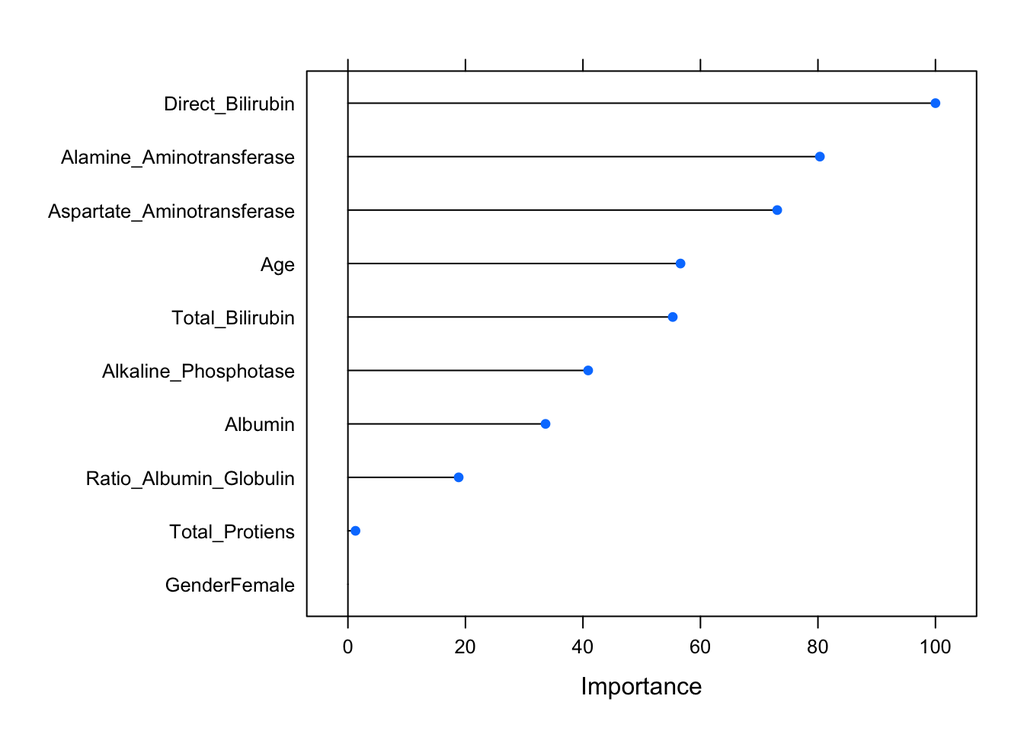

```r
rf_train %>%
  varImp %>%
  plot
```

```r
## The random forest model indicates that other variables are more important,
## as compared to the bagged model.
```

**10. Output the model output from the random forest. Are we doing better than with the bagged model?**

```r
rf_train
```

```
## Random Forest
##
## 500 samples
##  10 predictor
##   2 classes: 'Healthy', 'Disease'
##
## No pre-processing
## Resampling: Cross-Validated (10 fold, repeated 1 times)
## Summary of sample sizes: 450, 450, 450, 450, 450, 450, ...
## Resampling results across tuning parameters:
##
##   mtry  Accuracy  Kappa
##    2    0.704     0.1618056
##    6    0.688     0.1540873
##   10    0.690     0.1719310
##
## Accuracy was used to select the optimal model using the largest value.
## The final value used for the model was mtry = 2.
```

```r
## Yes, the most accurate model indicates that we do just slightly better than
## with the bagged model. However, this might well be due to chance.
```

**11. Now, fit a boosting model using the `caret` library to predict disease status.`**

*Hint:* Use gradient boosting (the `gbm` method in `caret`).

```r
gbm_train <- train(Disease ~ .,
                   data = df,
                   method = "gbm",
                   verbose = F,
                   trControl = cvcontrol)
```

**12. Again, interpret the variable importance measure. You will have to call for `summary()` on the model object you just created. Compare the output to the previously obtained variable importance measures.**

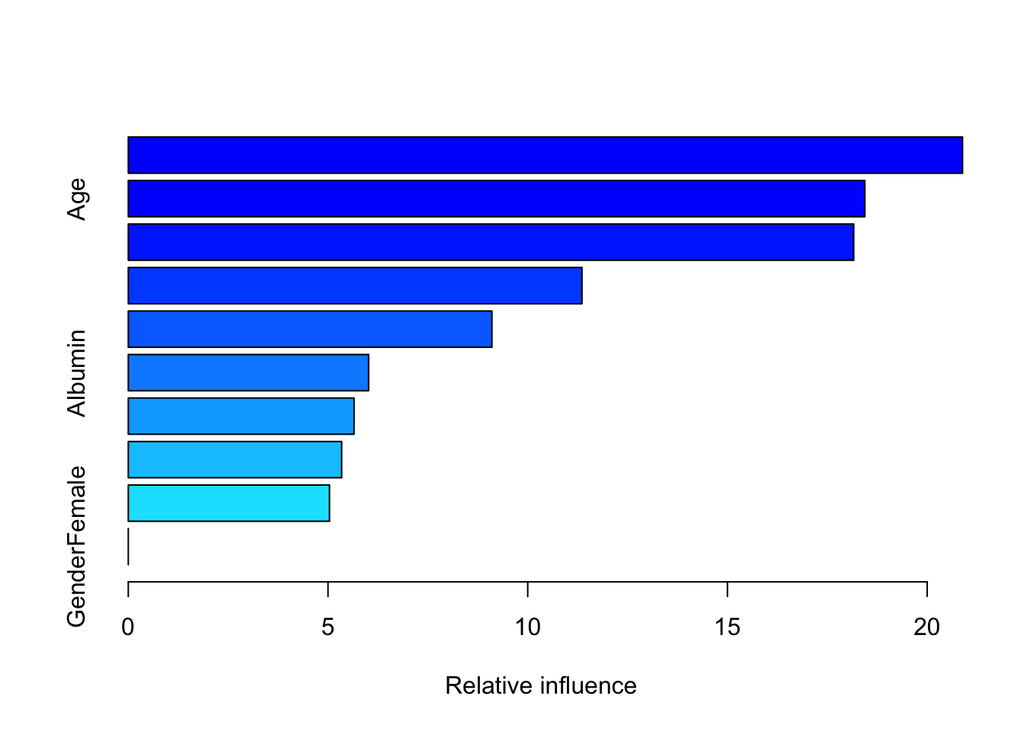

|  | var | rel.inf |
| --- | --- | --- |
| Aspartate_Aminotransferase | Aspartate_Aminotransferase | 20.886533 |
| Age | Age | 18.439905 |
| Alkaline_Phosphotase | Alkaline_Phosphotase | 18.162142 |
| Direct_Bilirubin | Direct_Bilirubin | 11.358766 |
| Alamine_Aminotransferase | Alamine_Aminotransferase | 9.103917 |
| Albumin | Albumin | 6.016757 |
| Total_Protiens | Total_Protiens | 5.652463 |
| Ratio_Albumin_Globulin | Ratio_Albumin_Globulin | 5.342127 |
| Total_Bilirubin | Total_Bilirubin | 5.037390 |
| GenderFemale | GenderFemale | 0.000000 |

```r
summary(gbm_train)
```

**13. Output the model output from our gradient boosting procedure. Are we doing better than with the bagged and random forest model?**

```r
gbm_train
```

```
## Stochastic Gradient Boosting
##
## 500 samples
##  10 predictor
##   2 classes: 'Healthy', 'Disease'
##
## No pre-processing
## Resampling: Cross-Validated (10 fold, repeated 1 times)
## Summary of sample sizes: 450, 450, 450, 450, 450, 450, ...
## Resampling results across tuning parameters:
##
##   interaction.depth  n.trees  Accuracy  Kappa
##   1                   50      0.708     0.1117547
##   1                  100      0.712     0.1700777
##   1                  150      0.708     0.1609721
##   2                   50      0.694     0.1084389
##   2                  100      0.680     0.1058856
##   2                  150      0.674     0.1042949
##   3                   50      0.694     0.1252223
##   3                  100      0.694     0.1545466
##   3                  150      0.688     0.1280794
##
## Tuning parameter 'shrinkage' was held constant at a value of 0.1
##
## Tuning parameter 'n.minobsinnode' was held constant at a value of 10
## Accuracy was used to select the optimal model using the largest value.
## The final values used for the model were n.trees = 100, interaction.depth =
##  1, shrinkage = 0.1 and n.minobsinnode = 10.
```

```r
# Yes, our best model is doing slightly better then the previous two models.
# However, this might still be random variation.
```

For now, we will continue with extreme gradient boosting, although we will use a difference procedure.

We will use `xgboost` to train a binary classification model, and create some visualizations to obtain additional insight in our model. We will create the visualizations using `SHAP` (**SH**apley **A**dditive ex**P**lanations) values, which are a measure of importance of the variables in the model. In fact, `SHAP` values indicate the influence of each input variable on the predicted probability for each person. Essentially, these give an indication of the difference between the predicted probability with and without that variable, for each person’s score.

**14. Download the file `shap.R` from [this](https://github.com/pablo14/shap-values) Github repository.**

*Note.* There are multiple ways to this, of which the simplest is to run the following code.

```r
library(devtools)
source_url("https://github.com/pablo14/shap-values/blob/master/shap.R?raw=TRUE")
```

Additionally, you could simply go to the file `shap.R` and copy-and-paste the code into the current repository. However, you could also fork and clone the repository, to make adjustments to the functions that are already created.

**15. Specify your model as follows, and use it to create predictions on the training data.**

```r
train_x <- model.matrix(Disease ~ ., df)[,-1]
train_y <- as.numeric(df$Disease) - 1
xgboost_train <- xgboost(data = train_x,
                         label = train_y,
                         max.depth = 10,
                         eta = 1,
                         nthread = 4,
                         nrounds = 4,
                         objective = "binary:logistic",
                         verbose = 2)



pred <- tibble(Disease = predict(xgboost_train, newdata = train_x)) %>%
  mutate(Disease = factor(ifelse(Disease < 0.5, 1, 2),
                          labels = c("Healthy", "Disease")))

table(pred$Disease, df$Disease)
```

[output not shown]

**16. First, calculate the `SHAP` rank scores for all variables in the data, and create a variable importance plot using these values. Interpret the plot.**

```r
shap_results <- shap.score.rank(xgboost_train,
                                X_train = train_x,
                                shap_approx = F)
```

```
## make SHAP score by decreasing order
```

```r
var_importance(shap_results)
```

[output not shown]

**17. Plot the `SHAP` values for every individual for every feature and interpret them.**

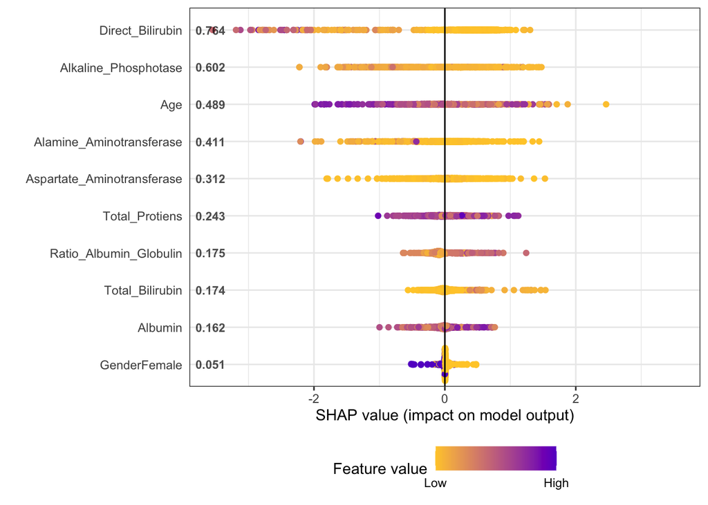

```r
shap_long <- shap.prep(shap = shap_results,
                       X_train = train_x)

plot.shap.summary(shap_long)
```

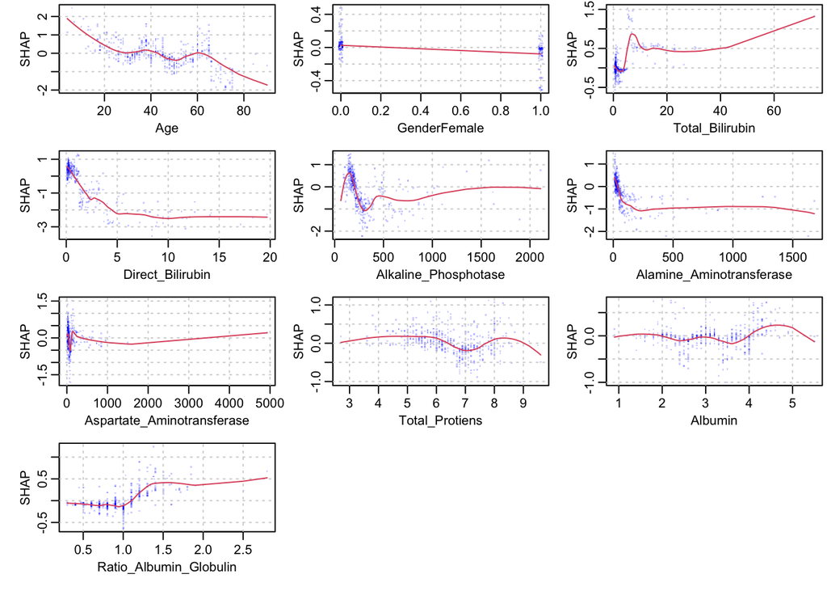

```r
xgb.plot.shap(train_x, features = colnames(train_x), model = xgboost_train, n_col = 3)
```

```r
## The first plot shows, for example, that those with a high value for
## Direct_Bilirubin have a lower probability of being diseased. Also,
## Those with a higher age have a lower probability of being diseased,
## while those with a higher Albumin have a higher probability of being diseased.

## The second set of plots displays the marginal relationships of the SHAP values with the predictors. This conveys the same information, but in greater detail. The interpretability may be a bit tricky for the inexperienced data analyst.
```

**18. Verify which of the models you created in this practical performs best on the test data.**

```r
test <- readRDS("data/test_disease.RDS")

bag_test <- predict(bag_train, newdata = test)
rf_test  <- predict(rf_train, newdata = test)
gbm_test <- predict(gbm_train, newdata = test)
xgb_test <- predict(xgboost_train, newdata = model.matrix(Disease ~ ., test)[,-1]) %>%
  factor(x = ifelse(. < 0.5, 1, 2), levels = c(1,2), labels = c("Healthy", "Disease"))

list(bag_test,
     rf_test,
     gbm_test,
     xgb_test) %>%
  map(~ confusionMatrix(.x, test$Disease))
```

```
## [[1]]
## Confusion Matrix and Statistics
##
##           Reference
## Prediction Healthy Disease
##    Healthy      48      16
##    Disease       6       9
##
##                Accuracy : 0.7215
##                  95% CI : (0.6093, 0.8165)
##     No Information Rate : 0.6835
##     P-Value [Acc > NIR] : 0.27598
##
##                   Kappa : 0.2788
##
##  Mcnemar's Test P-Value : 0.05501
##
##             Sensitivity : 0.8889
##             Specificity : 0.3600
##          Pos Pred Value : 0.7500
##          Neg Pred Value : 0.6000
##              Prevalence : 0.6835
##          Detection Rate : 0.6076
##    Detection Prevalence : 0.8101
##       Balanced Accuracy : 0.6244
##
##        'Positive' Class : Healthy
##
##
## [[2]]
## Confusion Matrix and Statistics
##
##           Reference
## Prediction Healthy Disease
##    Healthy      52      18
##    Disease       2       7
##
##                Accuracy : 0.7468
##                  95% CI : (0.6364, 0.838)
##     No Information Rate : 0.6835
```

[output cut: 60 more lines]

```
##                   Kappa : 0.2663
##
##  Mcnemar's Test P-Value : 0.5403
##
##             Sensitivity : 0.8148
##             Specificity : 0.4400
##          Pos Pred Value : 0.7586
##          Neg Pred Value : 0.5238
##              Prevalence : 0.6835
##          Detection Rate : 0.5570
##    Detection Prevalence : 0.7342
##       Balanced Accuracy : 0.6274
##
##        'Positive' Class : Healthy
##
```

# Hand-in

When you have finished the practical,

- enclose all files of the project `09_ensemble.Rproj` (i.e. all `.R` and/or `.Rmd` files including the one with your answers, and the `.Rproj` file) in a zip file, and
- hand in the zip by PR from your fork [here](https://github.com/gerkovink/INFOMDA1-2021). Try do so as soon as possible.